# Multi-Class Model for Tabular Playground Series February 2022 Using TensorFlow Decision Forests

### March 25, 2022

Template Credit: Adapted from a template made available by Dr. Jason Brownlee of Machine Learning Mastery. [https://machinelearningmastery.com/]

SUMMARY: This project aims to construct a predictive model using various machine learning algorithms and document the end-to-end steps using a template. The Tabular Playground Series February 2022 dataset is a multi-class modeling situation where we attempt to predict one of several (more than two) possible outcomes.

INTRODUCTION: Kaggle wants to provide an approachable environment for relatively new people in their data science journey. Since January 2021, they have hosted playground-style competitions on Kaggle with fun but less complex, tabular datasets. For this dataset, we want to predict bacteria species based on repeated lossy measurements of DNA snippets. Each row of data contains a spectrum of histograms generated by repeated measurements of a sample, and each row contains the output of all 286 histogram possibilities.

ANALYSIS: The performance of the preliminary Gradient Boosted Trees model achieved an accuracy benchmark of 99.36% on the training dataset. When we applied the finalized model to Kaggle's test dataset, the model achieved an accuracy score of 91.55%.

CONCLUSION: In this iteration, the TensorFlow Decision Forests model appeared to be a suitable algorithm for modeling this dataset.

Dataset Used: Tabular Playground Series February 2022

Dataset ML Model: Multi-Class classification with numerical features

Dataset Reference: https://www.kaggle.com/c/tabular-playground-series-feb-2022/data

One source of potential performance benchmarks: https://www.kaggle.com/c/tabular-playground-series-feb-2022/leaderboard

## Task 1 - Prepare Environment

```python
# Retrieve the CPU information
ncpu = !nproc
print("The number of available CPUs is:", ncpu[0])
```

```
The number of available CPUs is: 4
```

### 1.a) Load libraries and modules

```python
# Set the random seed number for reproducible results
RNG_SEED = 888
```

```python
import random
random.seed(RNG_SEED)
import numpy as np
np.random.seed(RNG_SEED)
import pandas as pd
import seaborn as sns
import matplotlib
import matplotlib.pyplot as plt
import os
import sys
import math
# import boto3
import zipfile
from datetime import datetime
from sklearn import preprocessing
from sklearn.model_selection import train_test_split
from sklearn.model_selection import RepeatedKFold
from sklearn.pipeline import Pipeline
from sklearn import compose
from sklearn import impute
from sklearn import metrics
import tensorflow as tf
tf.random.set_seed(RNG_SEED)
# from tensorflow import keras
import tensorflow_decision_forests as tfdf
```

[output not shown]

### 1.b) Set up the controlling parameters and functions

```python
# Begin the timer for the script processing
start_time_script = datetime.now()

# Set up the number of CPU cores available for multi-thread processing
N_JOBS = 1

# Set up the flag to stop sending progress emails (setting to True will send status emails!)
NOTIFY_STATUS = False

# Set the percentage sizes for splitting the dataset
TEST_SET_RATIO = 0.2
VAL_SET_RATIO = 0.2

# Set the number of folds for cross validation
N_FOLDS = 5
N_ITERATIONS = 1

# Set various default modeling parameters
DEFAULT_METRICS = ["accuracy", tf.keras.metrics.SparseCategoricalCrossentropy()]

# Define the directory locations and file names
IMPORT_DATASET = 'tabular-playground-series-feb-2022.zip'
TRAIN_DATASET = 'train.csv'
TEST_DATASET = 'test.csv'
SAMPLE_SUBMISSION = 'sample_submission.csv'
FINAL_SUBMISSION = 'submission_'

# # Check the number of GPUs accessible through TensorFlow
# print('Num GPUs Available:', len(tf.config.list_physical_devices('GPU')))

# Print out the TensorFlow version for confirmation
print('TensorFlow version:', tf.__version__)

# Check the version of TensorFlow Decision Forests
print("Found TensorFlow Decision Forests v" + tfdf.__version__)
```

```
TensorFlow version: 2.7.0
Found TensorFlow Decision Forests v0.2.1
```

[output not shown]

```python
# Set up the email notification function
def status_notify(msg_text):
    access_key = os.environ.get('SNS_ACCESS_KEY')
    secret_key = os.environ.get('SNS_SECRET_KEY')
    aws_region = os.environ.get('SNS_AWS_REGION')
    topic_arn = os.environ.get('SNS_TOPIC_ARN')
    if (access_key is None) or (secret_key is None) or (aws_region is None):
        sys.exit("Incomplete notification setup info. Script Processing Aborted!!!")
    sns = boto3.client('sns', aws_access_key_id=access_key, aws_secret_access_key=secret_key, region_name=aws_region)
    response = sns.publish(TopicArn=topic_arn, Message=msg_text)
    if response['ResponseMetadata']['HTTPStatusCode'] != 200 :
        print('Status notification not OK with HTTP status code:', response['ResponseMetadata']['HTTPStatusCode'])
```

```python
# Reset the random number generators
def reset_random(x=RNG_SEED):
    random.seed(x)
    np.random.seed(x)
    tf.random.set_seed(x)
```

```python
if NOTIFY_STATUS: status_notify("Task 1 - Prepare Environment has begun! " + datetime.now().strftime('%a %B %d, %Y %I:%M:%S %p'))
```

### 1.c) Load dataset

```python
# Clean up the old files and download directories before receiving new ones
# !rm Rice_Image_Dataset.zip
!rm sample_submission.csv
!rm train.csv
!rm test.csv
```

```
rm: cannot remove 'sample_submission.csv': No such file or directory
rm: cannot remove 'train.csv': No such file or directory
rm: cannot remove 'test.csv': No such file or directory
```

```python
if not os.path.exists(IMPORT_DATASET):
    !wget https://dainesanalytics.com/datasets/kaggle-tabular-playground-2022feb/tabular-playground-series-feb-2022.zip
```

```
--2022-03-15 19:01:43--  https://dainesanalytics.com/datasets/kaggle-tabular-playground-2022feb/tabular-playground-series-feb-2022.zip
Resolving dainesanalytics.com (dainesanalytics.com)... 13.226.230.91, 13.226.230.79, 13.226.230.77, ...
Connecting to dainesanalytics.com (dainesanalytics.com)|13.226.230.91|:443... connected.
HTTP request sent, awaiting response... 200 OK
Length: 279727694 (267M) [application/zip]
Saving to: ‘tabular-playground-series-feb-2022.zip’

tabular-playground- 100%[===================>] 266.77M  3.62MB/s    in 71s

2022-03-15 19:02:55 (3.74 MB/s) - ‘tabular-playground-series-feb-2022.zip’ saved [279727694/279727694]
```

```python
zip_ref = zipfile.ZipFile(IMPORT_DATASET, 'r')
zip_ref.extractall()
zip_ref.close()
```

```python
df_dataset_import = pd.read_csv(TRAIN_DATASET, index_col=False)

# Take a peek at the dataframe after import
print(df_dataset_import.head())
```

```
   row_id     A0T0G0C10  A0T0G1C9  A0T0G2C8  A0T0G3C7  A0T0G4C6  A0T0G5C5  \
0       0 -9.536743e-07 -0.000010 -0.000043 -0.000114 -0.000200 -0.000240
1       1 -9.536743e-07 -0.000010 -0.000043  0.000886 -0.000200  0.000760
2       2 -9.536743e-07 -0.000002  0.000007  0.000129  0.000268  0.000270
3       3  4.632568e-08 -0.000006  0.000012  0.000245  0.000492  0.000522
4       4 -9.536743e-07 -0.000010 -0.000043 -0.000114 -0.000200 -0.000240

   A0T0G6C4  A0T0G7C3  A0T0G8C2  ...  A8T0G1C1  A8T0G2C0  A8T1G0C1  A8T1G1C0  \
0 -0.000200 -0.000114 -0.000043  ... -0.000086 -0.000043 -0.000086 -0.000086
1 -0.000200 -0.000114 -0.000043  ... -0.000086 -0.000043  0.000914  0.000914
2  0.000243  0.000125  0.000001  ...  0.000084  0.000048  0.000081  0.000106
3  0.000396  0.000197 -0.000003  ...  0.000151  0.000100  0.000180  0.000202
4 -0.000200 -0.000114 -0.000043  ... -0.000086 -0.000043 -0.000086 -0.000086

   A8T2G0C0  A9T0G0C1  A9T0G1C0  A9T1G0C0     A10T0G0C0  \
0 -0.000043 -0.000010 -0.000010 -0.000010 -9.536743e-07
1 -0.000043 -0.000010 -0.000010 -0.000010 -9.536743e-07
2  0.000072  0.000010  0.000008  0.000019  1.046326e-06
3  0.000153  0.000021  0.000015  0.000046 -9.536743e-07
4 -0.000043 -0.000010 -0.000010 -0.000010 -9.536743e-07

                   target
0  Streptococcus_pyogenes
1     Salmonella_enterica
2     Salmonella_enterica
3     Salmonella_enterica
4      Enterococcus_hirae

[5 rows x 288 columns]
```

```python
df_dataset_import.info(verbose=True)
```

```
<class 'pandas.core.frame.DataFrame'>
RangeIndex: 200000 entries, 0 to 199999
Data columns (total 288 columns):
 #    Column     Dtype
---   ------     -----
 0    row_id     int64
 1    A0T0G0C10  float64
 2    A0T0G1C9   float64
 3    A0T0G2C8   float64
 4    A0T0G3C7   float64
 5    A0T0G4C6   float64
 6    A0T0G5C5   float64
 7    A0T0G6C4   float64
 8    A0T0G7C3   float64
 9    A0T0G8C2   float64
```

[output cut: 280 more lines]

```python
print(df_dataset_import.describe())
```

```
              row_id     A0T0G0C10       A0T0G1C9       A0T0G2C8  \
count  200000.000000  2.000000e+05  200000.000000  200000.000000
mean    99999.500000  6.421457e-07      -0.000003      -0.000014
std     57735.171256  8.654927e-05       0.000132       0.000287
min         0.000000 -9.536743e-07      -0.000010      -0.000043
25%     49999.750000 -9.536743e-07      -0.000010      -0.000043
50%     99999.500000 -9.536743e-07      -0.000010      -0.000043
75%    149999.250000 -9.536743e-07      -0.000003      -0.000013
max    199999.000000  9.999046e-03       0.009990       0.009957

            A0T0G3C7       A0T0G4C6       A0T0G5C5       A0T0G6C4  \
count  200000.000000  200000.000000  200000.000000  200000.000000
mean       -0.000010       0.000005       0.000025       0.000014
std         0.000436       0.000683       0.000869       0.000775
min        -0.000114      -0.000200      -0.000240      -0.000200
25%        -0.000114      -0.000200      -0.000240      -0.000200
50%        -0.000114      -0.000200      -0.000237      -0.000199
75%        -0.000004      -0.000011       0.000003      -0.000030
max         0.009886       0.019800       0.019760       0.019800

            A0T0G7C3       A0T0G8C2  ...       A8T0G0C2       A8T0G1C1  \
count  200000.000000  200000.000000  ...  200000.000000  200000.000000
mean       -0.000009      -0.000028  ...       0.000135       0.000348
std         0.000441       0.000107  ...       0.000711       0.001117
min        -0.000114      -0.000043  ...      -0.000043      -0.000086
25%        -0.000114      -0.000043  ...      -0.000043      -0.000086
50%        -0.000114      -0.000043  ...       0.000014       0.000064
75%         0.000004      -0.000028  ...       0.000111       0.000463
max         0.009886       0.009957  ...       0.019957       0.019914

            A8T0G2C0       A8T1G0C1       A8T1G1C0       A8T2G0C0  \
count  200000.000000  200000.000000  200000.000000  200000.000000
mean        0.000253       0.000464       0.000581       0.000379
std         0.000914       0.001238       0.001528       0.001182
min        -0.000043      -0.000086      -0.000086      -0.000043
25%        -0.000043      -0.000086      -0.000086      -0.000043
50%         0.000047       0.000124       0.000114       0.000043
75%         0.000297       0.000684       0.000774       0.000365
max         0.019957       0.019914       0.019914       0.019957

            A9T0G0C1      A9T0G1C0      A9T1G0C0     A10T0G0C0
count  200000.000000  2.000000e+05  2.000000e+05  2.000000e+05
mean        0.000062  8.982134e-05  1.170014e-04  2.215407e-07
std         0.000466  5.475606e-04  6.788277e-04  2.050081e-05
min        -0.000010 -9.536743e-06 -9.536743e-06 -9.536743e-07
25%        -0.000010 -9.536743e-06 -9.536743e-06 -9.536743e-07
50%        -0.000010  4.632568e-07  4.632568e-07 -9.536743e-07
75%         0.000030  6.046326e-05  6.946326e-05 -9.536743e-07
max         0.009990  9.990463e-03  1.999046e-02  9.990463e-04

[8 rows x 287 columns]
```

```python
print(df_dataset_import.isnull().sum())
print('Total number of NaN in the dataframe: ', df_dataset_import.isnull().sum().sum())
```

```
row_id       0
A0T0G0C10    0
A0T0G1C9     0
A0T0G2C8     0
A0T0G3C7     0
            ..
A9T0G0C1     0
A9T0G1C0     0
A9T1G0C0     0
A10T0G0C0    0
target       0
Length: 288, dtype: int64
Total number of NaN in the dataframe:  0
```

```python
# Get grouping size for the target variable
print(df_dataset_import.groupby('target').size())
```

```
target
Bacteroides_fragilis        20139
Campylobacter_jejuni        20063
Enterococcus_hirae          19947
Escherichia_coli            19958
Escherichia_fergusonii      19937
Klebsiella_pneumoniae       19847
Salmonella_enterica         20030
Staphylococcus_aureus       19929
Streptococcus_pneumoniae    20074
Streptococcus_pyogenes      20076
dtype: int64
```

### 1.d) Data Cleaning

```python
# Dropping features with all unique values or no variations
df_dataset_import.drop(columns=['row_id'], inplace=True)

# Transform the classes into integers
label_encoder = preprocessing.LabelEncoder()
df_dataset_import['target'] = label_encoder.fit_transform(df_dataset_import['target'])

# Take a peek at the dataframe after cleaning
print(df_dataset_import.head())
```

```
      A0T0G0C10  A0T0G1C9  A0T0G2C8  A0T0G3C7  A0T0G4C6  A0T0G5C5  A0T0G6C4  \
0 -9.536743e-07 -0.000010 -0.000043 -0.000114 -0.000200 -0.000240 -0.000200
1 -9.536743e-07 -0.000010 -0.000043  0.000886 -0.000200  0.000760 -0.000200
2 -9.536743e-07 -0.000002  0.000007  0.000129  0.000268  0.000270  0.000243
3  4.632568e-08 -0.000006  0.000012  0.000245  0.000492  0.000522  0.000396
4 -9.536743e-07 -0.000010 -0.000043 -0.000114 -0.000200 -0.000240 -0.000200

   A0T0G7C3  A0T0G8C2  A0T0G9C1  ...  A8T0G1C1  A8T0G2C0  A8T1G0C1  A8T1G1C0  \
0 -0.000114 -0.000043 -0.000010  ... -0.000086 -0.000043 -0.000086 -0.000086
1 -0.000114 -0.000043 -0.000010  ... -0.000086 -0.000043  0.000914  0.000914
2  0.000125  0.000001 -0.000007  ...  0.000084  0.000048  0.000081  0.000106
3  0.000197 -0.000003 -0.000007  ...  0.000151  0.000100  0.000180  0.000202
4 -0.000114 -0.000043 -0.000010  ... -0.000086 -0.000043 -0.000086 -0.000086

   A8T2G0C0  A9T0G0C1  A9T0G1C0  A9T1G0C0     A10T0G0C0  target
0 -0.000043 -0.000010 -0.000010 -0.000010 -9.536743e-07       9
1 -0.000043 -0.000010 -0.000010 -0.000010 -9.536743e-07       6
2  0.000072  0.000010  0.000008  0.000019  1.046326e-06       6
3  0.000153  0.000021  0.000015  0.000046 -9.536743e-07       6
4 -0.000043 -0.000010 -0.000010 -0.000010 -9.536743e-07       2

[5 rows x 287 columns]
```

```python
df_dataset_import.info(verbose=True)
```

```
<class 'pandas.core.frame.DataFrame'>
RangeIndex: 200000 entries, 0 to 199999
Data columns (total 287 columns):
 #    Column     Dtype
---   ------     -----
 0    A0T0G0C10  float64
 1    A0T0G1C9   float64
 2    A0T0G2C8   float64
 3    A0T0G3C7   float64
 4    A0T0G4C6   float64
 5    A0T0G5C5   float64
 6    A0T0G6C4   float64
 7    A0T0G7C3   float64
 8    A0T0G8C2   float64
 9    A0T0G9C1   float64
```

[output cut: 279 more lines]

```python
print(df_dataset_import.describe())
```

```
          A0T0G0C10       A0T0G1C9       A0T0G2C8       A0T0G3C7  \
count  2.000000e+05  200000.000000  200000.000000  200000.000000
mean   6.421457e-07      -0.000003      -0.000014      -0.000010
std    8.654927e-05       0.000132       0.000287       0.000436
min   -9.536743e-07      -0.000010      -0.000043      -0.000114
25%   -9.536743e-07      -0.000010      -0.000043      -0.000114
50%   -9.536743e-07      -0.000010      -0.000043      -0.000114
75%   -9.536743e-07      -0.000003      -0.000013      -0.000004
max    9.999046e-03       0.009990       0.009957       0.009886

            A0T0G4C6       A0T0G5C5       A0T0G6C4       A0T0G7C3  \
count  200000.000000  200000.000000  200000.000000  200000.000000
mean        0.000005       0.000025       0.000014      -0.000009
std         0.000683       0.000869       0.000775       0.000441
min        -0.000200      -0.000240      -0.000200      -0.000114
25%        -0.000200      -0.000240      -0.000200      -0.000114
50%        -0.000200      -0.000237      -0.000199      -0.000114
75%        -0.000011       0.000003      -0.000030       0.000004
max         0.019800       0.019760       0.019800       0.009886

            A0T0G8C2       A0T0G9C1  ...       A8T0G1C1       A8T0G2C0  \
count  200000.000000  200000.000000  ...  200000.000000  200000.000000
mean       -0.000028      -0.000008  ...       0.000348       0.000253
std         0.000107       0.000083  ...       0.001117       0.000914
min        -0.000043      -0.000010  ...      -0.000086      -0.000043
25%        -0.000043      -0.000010  ...      -0.000086      -0.000043
50%        -0.000043      -0.000010  ...       0.000064       0.000047
75%        -0.000028      -0.000010  ...       0.000463       0.000297
max         0.009957       0.009990  ...       0.019914       0.019957

            A8T1G0C1       A8T1G1C0       A8T2G0C0       A9T0G0C1  \
count  200000.000000  200000.000000  200000.000000  200000.000000
mean        0.000464       0.000581       0.000379       0.000062
std         0.001238       0.001528       0.001182       0.000466
min        -0.000086      -0.000086      -0.000043      -0.000010
25%        -0.000086      -0.000086      -0.000043      -0.000010
50%         0.000124       0.000114       0.000043      -0.000010
75%         0.000684       0.000774       0.000365       0.000030
max         0.019914       0.019914       0.019957       0.009990

           A9T0G1C0      A9T1G0C0     A10T0G0C0         target
count  2.000000e+05  2.000000e+05  2.000000e+05  200000.000000
mean   8.982134e-05  1.170014e-04  2.215407e-07       4.498865
std    5.475606e-04  6.788277e-04  2.050081e-05       2.876790
min   -9.536743e-06 -9.536743e-06 -9.536743e-07       0.000000
25%   -9.536743e-06 -9.536743e-06 -9.536743e-07       2.000000
50%    4.632568e-07  4.632568e-07 -9.536743e-07       4.000000
75%    6.046326e-05  6.946326e-05 -9.536743e-07       7.000000
max    9.990463e-03  1.999046e-02  9.990463e-04       9.000000

[8 rows x 287 columns]
```

```python
print(df_dataset_import.isnull().sum())
print('Total number of NaN in the dataframe: ', df_dataset_import.isnull().sum().sum())
```

```
A0T0G0C10    0
A0T0G1C9     0
A0T0G2C8     0
A0T0G3C7     0
A0T0G4C6     0
            ..
A9T0G0C1     0
A9T0G1C0     0
A9T1G0C0     0
A10T0G0C0    0
target       0
Length: 287, dtype: int64
Total number of NaN in the dataframe:  0
```

```python
# Get grouping size for the target variable
print(df_dataset_import.groupby('target').size())
```

```
target
0    20139
1    20063
2    19947
3    19958
4    19937
5    19847
6    20030
7    19929
8    20074
9    20076
dtype: int64
```

### 1.e) Splitting Data into Sets

```python
# Use variable total_column_count to hold the number of columns in the dataframe
total_column_count = len(df_dataset_import.columns)

# Set up variable total_feature_count for the total number of attribute columns
total_feature_count = total_column_count-1

# We create attribute-only and target-only datasets (df_features_train and df_target_train)
df_target_train = df_dataset_import['target']
df_features_train = df_dataset_import.drop(['target'], axis=1)

print("df_dataset_import.shape: {} df_features_train.shape: {} df_target_train.shape: {}".format(df_dataset_import.shape, df_features_train.shape, df_target_train.shape))
```

```
df_dataset_import.shape: (200000, 287) df_features_train.shape: (200000, 286) df_target_train.shape: (200000,)
```

### 1.f) Set up the parameters for data visualization

```python
# Set up the number of row and columns for visualization display. display_rows * display_columns should be >= total_feature_count
display_columns = 4
if total_feature_count % display_columns == 0 :
    display_rows = total_feature_count // display_columns
else :
    display_rows = (total_feature_count // display_columns) + 1

# Set figure width to display the data visualization plots
fig_size = plt.rcParams["figure.figsize"]
fig_size[0] = display_columns * 4
fig_size[1] = display_rows * 4
plt.rcParams["figure.figsize"] = fig_size
```

```python
if NOTIFY_STATUS: status_notify("Task 1 - Prepare Environment completed! "+datetime.now().strftime('%a %B %d, %Y %I:%M:%S %p'))
```

## Task 2 - Summarize and Visualize Data

```python
if NOTIFY_STATUS: status_notify("Task 2 - Summarize and Visualize Data has begun! "+datetime.now().strftime('%a %B %d, %Y %I:%M:%S %p'))
```

[figure not shown]

```python
# Histograms for each attribute
df_features_train.plot(kind='hist', subplots=True, layout=(display_rows, display_columns))
plt.show()
```

[figure not shown]

```python
# Box and Whisker plot for each attribute
df_features_train.plot(kind='box', subplots=True, layout=(display_rows, display_columns))
plt.show()
```

```python
# # Correlation matrix
# fig = plt.figure(figsize=(20, 20))
# correlations = df_features_train.corr(method='pearson')
# sns.heatmap(correlations, annot=True, cmap=plt.cm.PuBu)
# plt.show()
```

```python
if NOTIFY_STATUS: status_notify("Task 2 - Summarize and Visualize Data completed! "+datetime.now().strftime('%a %B %d, %Y %I:%M:%S %p'))
```

## Task 3 - Train and Evaluate Models

```python
if NOTIFY_STATUS: status_notify("Task 3 - Train and Evaluate Models has begun! "+datetime.now().strftime('%a %B %d, %Y %I:%M:%S %p'))
```

### 3.a) Splitting Data into Training and Validation Sets

```python
# Finalize the training and validation datasets for the modeling activities
tfds_train = tfdf.keras.pd_dataframe_to_tf_dataset(df_dataset_import, label='target', task = tfdf.keras.Task.CLASSIFICATION)
```

### 3.b) Train and Evaluate the Random Forest Model

```python
# Define the baseline model for benchmarking
start_time_module = datetime.now()
reset_random()
RF_model = tfdf.keras.RandomForestModel(task = tfdf.keras.Task.CLASSIFICATION)
RF_model.compile(metrics=DEFAULT_METRICS)

# "sys_pipes" is optional. It enables the display of the training logs.
# with sys_pipes():
#     RF_model.fit(x=tfds_train)

# Train the model.
RF_model.fit(x=tfds_train)
print ('Model training time:', (datetime.now() - start_time_module), '\n')
```

[output not shown]

[output cut: 633 more lines]

```
[INFO random_forest.cc:628] Training of tree  246/300 (tree index:246) done accuracy:0.96115 logloss:0.292775
[INFO random_forest.cc:628] Training of tree  254/300 (tree index:253) done accuracy:0.961295 logloss:0.292694
[INFO random_forest.cc:628] Training of tree  262/300 (tree index:262) done accuracy:0.96142 logloss:0.292313
[INFO random_forest.cc:628] Training of tree  269/300 (tree index:270) done accuracy:0.96148 logloss:0.29212
[INFO random_forest.cc:628] Training of tree  277/300 (tree index:277) done accuracy:0.96154 logloss:0.291421
[INFO random_forest.cc:628] Training of tree  285/300 (tree index:285) done accuracy:0.961755 logloss:0.290995
[INFO random_forest.cc:628] Training of tree  292/300 (tree index:292) done accuracy:0.96206 logloss:0.290362
[INFO random_forest.cc:628] Training of tree  300/300 (tree index:298) done accuracy:0.962025 logloss:0.290654
[INFO random_forest.cc:696] Final OOB metrics: accuracy:0.962025 logloss:0.290654
[INFO kernel.cc:828] Export model in log directory: /tmp/tmpkerf4wt5
[INFO kernel.cc:836] Save model in resources
[INFO kernel.cc:988] Loading model from path
[INFO decision_forest.cc:590] Model loaded with 300 root(s), 1998574 node(s), and 286 input feature(s).
[INFO abstract_model.cc:993] Engine "RandomForestGeneric" built
[INFO kernel.cc:848] Use fast generic engine
```

```
Model training time: 0:12:56.585553
```

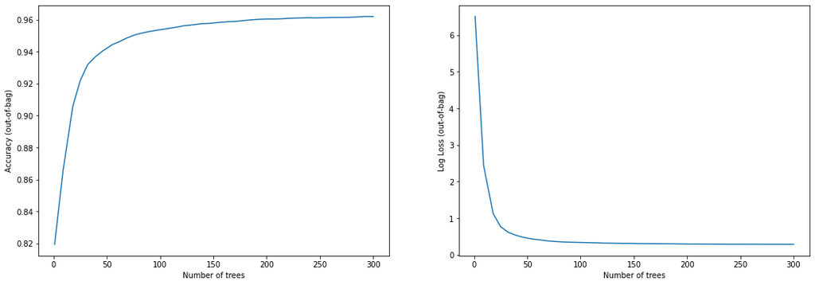

```python
logs = RF_model.make_inspector().training_logs()

plt.figure(figsize=(18, 6))
plt.subplot(1, 2, 1)
plt.plot([log.num_trees for log in logs], [log.evaluation.accuracy for log in logs])
plt.xlabel("Number of trees")
plt.ylabel("Accuracy (out-of-bag)")
plt.subplot(1, 2, 2)
plt.plot([log.num_trees for log in logs], [log.evaluation.loss for log in logs])
plt.xlabel("Number of trees")
plt.ylabel("Log Loss (out-of-bag)")
plt.show()
```

```python
RF_eval = RF_model.evaluate(tfds_train, return_dict=True)
print()

for name, value in RF_eval.items():
    print(f"{name}: {value:.4f}")
```

```
loss: 0.0000
accuracy: 0.9706
sparse_categorical_crossentropy: 0.2443
```

### 3.c) Train and Evaluate the Decision Trees Model

```python
# Define the baseline model for benchmarking
start_time_module = datetime.now()
reset_random()
CART_model = tfdf.keras.CartModel(task = tfdf.keras.Task.CLASSIFICATION)
CART_model.compile(metrics=DEFAULT_METRICS)

# "sys_pipes" is optional. It enables the display of the training logs.
# with sys_pipes():
#     CART_model.fit(x=tfds_train)

# Train the model.
CART_model.fit(x=tfds_train)
print ('Model training time:', (datetime.now() - start_time_module), '\n')
```

[output not shown]

[output cut: 582 more lines]

```
    num_candidate_attributes_ratio: -1
    axis_aligned_split {
    }
    internal {
      sorting_strategy: PRESORTED
    }
  }
  validation_ratio: 0.1
}

[INFO kernel.cc:790] Deployment config:
num_threads: 6

[INFO kernel.cc:817] Train model
[INFO cart.cc:174] Training CART on 200000 example(s) and 286 feature(s).
```

```
[INFO cart.cc:375] 6401 nodes before pruning. 3899 nodes after pruning.
[INFO kernel.cc:828] Export model in log directory: /tmp/tmpp2mmf16c
[INFO kernel.cc:836] Save model in resources
[INFO kernel.cc:988] Loading model from path
[INFO decision_forest.cc:590] Model loaded with 1 root(s), 3899 node(s), and 265 input feature(s).
[INFO abstract_model.cc:993] Engine "RandomForestGeneric" built
[INFO kernel.cc:848] Use fast generic engine
```

```
Model training time: 0:03:35.162083
```

```python
CART_eval = CART_model.evaluate(tfds_train, return_dict=True)
print()

for name, value in CART_eval.items():
    print(f"{name}: {value:.4f}")
```

```
loss: 0.0000
accuracy: 0.8134
sparse_categorical_crossentropy: 0.3623
```

### 3.d) Train and Evaluate the Gradient Boosted Trees Model

```python
# Define the baseline model for benchmarking
start_time_module = datetime.now()
reset_random()
GBT_model = tfdf.keras.GradientBoostedTreesModel(task = tfdf.keras.Task.CLASSIFICATION)
GBT_model.compile(metrics=DEFAULT_METRICS)

# "sys_pipes" is optional. It enables the display of the training logs.
# with sys_pipes():
#     GBT_model.fit(x=tfds_train)

# Train the model.
GBT_model.fit(x=tfds_train)
print ('Model training time:', (datetime.now() - start_time_module), '\n')
```

[output not shown]

[output cut: 907 more lines]

```
[INFO gradient_boosted_trees.cc:1428] 	num-trees:291 train-loss:0.069015 train-accuracy:0.993904 valid-loss:0.090737 valid-accuracy:0.986078
[INFO gradient_boosted_trees.cc:1428] 	num-trees:292 train-loss:0.068674 train-accuracy:0.993904 valid-loss:0.090393 valid-accuracy:0.985978
[INFO gradient_boosted_trees.cc:1428] 	num-trees:293 train-loss:0.068360 train-accuracy:0.993965 valid-loss:0.090061 valid-accuracy:0.986228
[INFO gradient_boosted_trees.cc:1428] 	num-trees:294 train-loss:0.068026 train-accuracy:0.994004 valid-loss:0.089699 valid-accuracy:0.986327
[INFO gradient_boosted_trees.cc:1428] 	num-trees:295 train-loss:0.067658 train-accuracy:0.994160 valid-loss:0.089285 valid-accuracy:0.986377
[INFO gradient_boosted_trees.cc:1428] 	num-trees:296 train-loss:0.067360 train-accuracy:0.994210 valid-loss:0.088986 valid-accuracy:0.986327
[INFO gradient_boosted_trees.cc:1428] 	num-trees:297 train-loss:0.067070 train-accuracy:0.994271 valid-loss:0.088665 valid-accuracy:0.986377
[INFO gradient_boosted_trees.cc:1428] 	num-trees:298 train-loss:0.066711 train-accuracy:0.994382 valid-loss:0.088276 valid-accuracy:0.986427
[INFO gradient_boosted_trees.cc:1428] 	num-trees:299 train-loss:0.066399 train-accuracy:0.994415 valid-loss:0.087920 valid-accuracy:0.986527
[INFO gradient_boosted_trees.cc:1426] 	num-trees:300 train-loss:0.066051 train-accuracy:0.994432 valid-loss:0.087567 valid-accuracy:0.986427
[INFO gradient_boosted_trees.cc:229] Truncates the model to 3000 tree(s) i.e. 300  iteration(s).
[INFO gradient_boosted_trees.cc:263] Final model num-trees:300 valid-loss:0.087567 valid-accuracy:0.986427
[INFO kernel.cc:828] Export model in log directory: /tmp/tmpx0a_9arj
[INFO kernel.cc:836] Save model in resources
[INFO kernel.cc:988] Loading model from path
```

```
[INFO decision_forest.cc:590] Model loaded with 3000 root(s), 172930 node(s), and 286 input feature(s).
[INFO abstract_model.cc:993] Engine "GradientBoostedTreesGeneric" built
[INFO kernel.cc:848] Use fast generic engine
```

```
Model training time: 2:44:41.094704
```

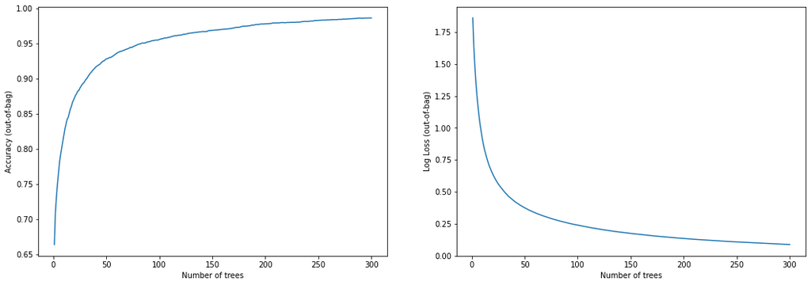

```python
logs = GBT_model.make_inspector().training_logs()

plt.figure(figsize=(18, 6))
plt.subplot(1, 2, 1)
plt.plot([log.num_trees for log in logs], [log.evaluation.accuracy for log in logs])
plt.xlabel("Number of trees")
plt.ylabel("Accuracy (out-of-bag)")
plt.subplot(1, 2, 2)
plt.plot([log.num_trees for log in logs], [log.evaluation.loss for log in logs])
plt.xlabel("Number of trees")
plt.ylabel("Log Loss (out-of-bag)")
plt.show()
```

```python
GBT_eval = GBT_model.evaluate(tfds_train, return_dict=True)
print()

for name, value in GBT_eval.items():
    print(f"{name}: {value:.4f}")
```

```
loss: 0.0000
accuracy: 0.9936
sparse_categorical_crossentropy: 0.2643
```

```python
if NOTIFY_STATUS: status_notify("Task 4 - Train and Evaluate Models completed! "+datetime.now().strftime('%a %B %d, %Y %I:%M:%S %p'))
```

## Task 4 - Fine-tune and Improve Models

```python
if NOTIFY_STATUS: status_notify("Task 4 - Fine-tune and Improve Models has begun! "+datetime.now().strftime('%a %B %d, %Y %I:%M:%S %p'))
```

```python
# Not applicable for this iteration of modeling
```

```python
if NOTIFY_STATUS: status_notify("Task 4 - Fine-tune and Improve Models completed! "+datetime.now().strftime('%a %B %d, %Y %I:%M:%S %p'))
```

## Task 5 - Finalize Model and Present Analysis

```python
if NOTIFY_STATUS: status_notify("Task 5 - Finalize Model and Present Analysis has begun! "+datetime.now().strftime('%a %B %d, %Y %I:%M:%S %p'))
```

### 5.a) Train the Final Model

```python
# Define the baseline model for benchmarking
start_time_module = datetime.now()
reset_random()
# final_model = tfdf.keras.RandomForestModel(task = tfdf.keras.Task.CLASSIFICATION)
# final_model = tfdf.keras.CartModel(task = tfdf.keras.Task.CLASSIFICATION)
final_model = tfdf.keras.GradientBoostedTreesModel(task = tfdf.keras.Task.CLASSIFICATION)

# Optionally, add evaluation metrics.
final_model.compile(metrics=DEFAULT_METRICS)

# "sys_pipes" is optional. It enables the display of the training logs.
# with sys_pipes():
#     final_model.fit(x=tfds_train)

# Train the model.
final_model.fit(x=tfds_train)
print ('Model training time:', (datetime.now() - start_time_module), '\n')
```

[output not shown]

[output cut: 907 more lines]

```
[INFO gradient_boosted_trees.cc:1428] 	num-trees:291 train-loss:0.069015 train-accuracy:0.993904 valid-loss:0.090737 valid-accuracy:0.986078
[INFO gradient_boosted_trees.cc:1428] 	num-trees:292 train-loss:0.068674 train-accuracy:0.993904 valid-loss:0.090393 valid-accuracy:0.985978
[INFO gradient_boosted_trees.cc:1428] 	num-trees:293 train-loss:0.068360 train-accuracy:0.993965 valid-loss:0.090061 valid-accuracy:0.986228
[INFO gradient_boosted_trees.cc:1428] 	num-trees:294 train-loss:0.068026 train-accuracy:0.994004 valid-loss:0.089699 valid-accuracy:0.986327
[INFO gradient_boosted_trees.cc:1428] 	num-trees:295 train-loss:0.067658 train-accuracy:0.994160 valid-loss:0.089285 valid-accuracy:0.986377
[INFO gradient_boosted_trees.cc:1428] 	num-trees:296 train-loss:0.067360 train-accuracy:0.994210 valid-loss:0.088986 valid-accuracy:0.986327
[INFO gradient_boosted_trees.cc:1428] 	num-trees:297 train-loss:0.067070 train-accuracy:0.994271 valid-loss:0.088665 valid-accuracy:0.986377
[INFO gradient_boosted_trees.cc:1428] 	num-trees:298 train-loss:0.066711 train-accuracy:0.994382 valid-loss:0.088276 valid-accuracy:0.986427
[INFO gradient_boosted_trees.cc:1428] 	num-trees:299 train-loss:0.066399 train-accuracy:0.994415 valid-loss:0.087920 valid-accuracy:0.986527
[INFO gradient_boosted_trees.cc:1426] 	num-trees:300 train-loss:0.066051 train-accuracy:0.994432 valid-loss:0.087567 valid-accuracy:0.986427
[INFO gradient_boosted_trees.cc:229] Truncates the model to 3000 tree(s) i.e. 300  iteration(s).
[INFO gradient_boosted_trees.cc:263] Final model num-trees:300 valid-loss:0.087567 valid-accuracy:0.986427
[INFO kernel.cc:828] Export model in log directory: /tmp/tmpbcfqopet
[INFO kernel.cc:836] Save model in resources
[INFO kernel.cc:988] Loading model from path
```

```
[INFO decision_forest.cc:590] Model loaded with 3000 root(s), 172930 node(s), and 286 input feature(s).
[INFO abstract_model.cc:993] Engine "GradientBoostedTreesGeneric" built
[INFO kernel.cc:848] Use fast generic engine
```

```
Model training time: 2:47:35.568990
```

```python
final_model.summary()
```

```
Model: "gradient_boosted_trees_model_1"
_________________________________________________________________
 Layer (type)                Output Shape              Param #
=================================================================
=================================================================
Total params: 1
Trainable params: 0
Non-trainable params: 1
_________________________________________________________________
Type: "GRADIENT_BOOSTED_TREES"
Task: CLASSIFICATION
Label: "__LABEL"

Input Features (286):
	A0T0G0C10
	A0T0G10C0
	A0T0G1C9
	A0T0G2C8
	A0T0G3C7
	A0T0G4C6
	A0T0G5C5
	A0T0G6C4
	A0T0G7C3
	A0T0G8C2
	A0T0G9C1
	A0T10G0C0
	A0T1G0C9
	A0T1G1C8
	A0T1G2C7
	A0T1G3C6
	A0T1G4C5
	A0T1G5C4
	A0T1G6C3
	A0T1G7C2
	A0T1G8C1
	A0T1G9C0
	A0T2G0C8
	A0T2G1C7
	A0T2G2C6
	A0T2G3C5
```

[output cut: 3118 more lines]

```
	9 : A1T0G0C9 [NUMERICAL]
	5 : A0T0G10C0 [NUMERICAL]

Condition type in nodes:
	84965 : HigherCondition
Condition type in nodes with depth <= 0:
	3000 : HigherCondition
Condition type in nodes with depth <= 1:
	8991 : HigherCondition
Condition type in nodes with depth <= 2:
	20807 : HigherCondition
Condition type in nodes with depth <= 3:
	43437 : HigherCondition
Condition type in nodes with depth <= 5:
	84965 : HigherCondition
```

### 5.b) Load Test Dataset and Make Predictions

```python
df_features_test = pd.read_csv(TEST_DATASET, index_col=False)

# Take a peek at the dataframe after import
print(df_features_test.head())
```

```
   row_id     A0T0G0C10  A0T0G1C9      A0T0G2C8  A0T0G3C7  A0T0G4C6  A0T0G5C5  \
0  200000 -9.536743e-07 -0.000002 -9.153442e-07  0.000024  0.000034 -0.000002
1  200001 -9.536743e-07 -0.000010 -4.291534e-05 -0.000114  0.001800 -0.000240
2  200002  4.632568e-08  0.000003  8.465576e-08 -0.000014  0.000007 -0.000005
3  200003 -9.536743e-07 -0.000008  8.084656e-06  0.000216  0.000420  0.000514
4  200004 -9.536743e-07 -0.000010 -4.291534e-05 -0.000114 -0.000200 -0.000240

   A0T0G6C4  A0T0G7C3  A0T0G8C2  ...  A8T0G0C2  A8T0G1C1  A8T0G2C0  A8T1G0C1  \
0  0.000021  0.000024 -0.000009  ...  0.000039  0.000085  0.000055  0.000108
1  0.001800 -0.000114  0.000957  ... -0.000043  0.000914 -0.000043 -0.000086
2 -0.000004  0.000003  0.000004  ...  0.000041  0.000102  0.000084  0.000111
3  0.000452  0.000187 -0.000005  ...  0.000069  0.000158  0.000098  0.000175
4 -0.000200 -0.000114 -0.000043  ... -0.000043 -0.000086 -0.000043 -0.000086

   A8T1G1C0  A8T2G0C0  A9T0G0C1  A9T0G1C0  A9T1G0C0     A10T0G0C0
0  0.000090  0.000059  0.000010  0.000006  0.000027  4.632568e-08
1 -0.000086 -0.000043 -0.000010 -0.000010 -0.000010 -9.536743e-07
2  0.000117  0.000070  0.000020  0.000030  0.000021  4.632568e-08
3  0.000217  0.000150  0.000018  0.000016  0.000051 -9.536743e-07
4  0.000914 -0.000043 -0.000010 -0.000010  0.000990 -9.536743e-07

[5 rows x 287 columns]
```

```python
id_column_name = df_features_test.columns[0]
df_kaggle_submission = pd.DataFrame()
df_kaggle_submission[id_column_name] = df_features_test[id_column_name]
print(df_kaggle_submission.head())
```

```
   row_id
0  200000
1  200001
2  200002
3  200003
4  200004
```

```python
# Dropping unnecessary features
df_features_test.drop(columns=[id_column_name], inplace=True)

# Take a peek at the dataframe after cleaning
print(df_features_test.head())
```

```
      A0T0G0C10  A0T0G1C9      A0T0G2C8  A0T0G3C7  A0T0G4C6  A0T0G5C5  \
0 -9.536743e-07 -0.000002 -9.153442e-07  0.000024  0.000034 -0.000002
1 -9.536743e-07 -0.000010 -4.291534e-05 -0.000114  0.001800 -0.000240
2  4.632568e-08  0.000003  8.465576e-08 -0.000014  0.000007 -0.000005
3 -9.536743e-07 -0.000008  8.084656e-06  0.000216  0.000420  0.000514
4 -9.536743e-07 -0.000010 -4.291534e-05 -0.000114 -0.000200 -0.000240

   A0T0G6C4  A0T0G7C3  A0T0G8C2  A0T0G9C1  ...  A8T0G0C2  A8T0G1C1  A8T0G2C0  \
0  0.000021  0.000024 -0.000009 -0.000008  ...  0.000039  0.000085  0.000055
1  0.001800 -0.000114  0.000957 -0.000010  ... -0.000043  0.000914 -0.000043
2 -0.000004  0.000003  0.000004 -0.000008  ...  0.000041  0.000102  0.000084
3  0.000452  0.000187 -0.000005 -0.000008  ...  0.000069  0.000158  0.000098
4 -0.000200 -0.000114 -0.000043 -0.000010  ... -0.000043 -0.000086 -0.000043

   A8T1G0C1  A8T1G1C0  A8T2G0C0  A9T0G0C1  A9T0G1C0  A9T1G0C0     A10T0G0C0
0  0.000108  0.000090  0.000059  0.000010  0.000006  0.000027  4.632568e-08
1 -0.000086 -0.000086 -0.000043 -0.000010 -0.000010 -0.000010 -9.536743e-07
2  0.000111  0.000117  0.000070  0.000020  0.000030  0.000021  4.632568e-08
3  0.000175  0.000217  0.000150  0.000018  0.000016  0.000051 -9.536743e-07
4 -0.000086  0.000914 -0.000043 -0.000010 -0.000010  0.000990 -9.536743e-07

[5 rows x 286 columns]
```

```python
# Finalize the test dataset for the prediction activities
tfds_test = tfdf.keras.pd_dataframe_to_tf_dataset(df_features_test, task = tfdf.keras.Task.CLASSIFICATION)
```

```python
# Make batched predictions
test_predictions = label_encoder.inverse_transform(np.argmax(final_model.predict(tfds_test), axis=-1))
print(test_predictions)
```

[output not shown]

[output not shown]

```
['Escherichia_fergusonii' 'Salmonella_enterica' 'Enterococcus_hirae' ...
 'Bacteroides_fragilis' 'Bacteroides_fragilis' 'Streptococcus_pyogenes']
```

```python
df_sample_submission = pd.read_csv(SAMPLE_SUBMISSION, index_col=False)
df_sample_submission.drop(columns=[id_column_name], inplace=True)
submission_header = list(df_sample_submission.columns)
print(submission_header)
```

```
['target']
```

```python
df_kaggle_submission[submission_header[0]] = test_predictions
print(df_kaggle_submission.head())
```

```
   row_id                  target
0  200000  Escherichia_fergusonii
1  200001     Salmonella_enterica
2  200002      Enterococcus_hirae
3  200003     Salmonella_enterica
4  200004   Staphylococcus_aureus
```

```python
submission_file = df_kaggle_submission.to_csv(header=True, index=False)
filename = FINAL_SUBMISSION + datetime.now().strftime('%Y%m%d-%H%M') + '.csv'
with open(filename, 'w') as f:
    f.write(submission_file)
    print('Completed writing output file: ' + filename)
```

```
Completed writing output file: submission_20220316-0111.csv
```

```python
if NOTIFY_STATUS: status_notify("Task 5 - Finalize Model and Present Analysis completed! "+datetime.now().strftime('%a %B %d, %Y %I:%M:%S %p'))
```

```python
print ('Total time for the script:',(datetime.now() - start_time_script))
```

```
Total time for the script: 6:10:15.462298
```